# HW2

TO 414

1/26/2018

1. In last HW we explored which airlines are better/worse as far as arrival delay is concerned. We now want to know whether airlines actually make up time when on air. Create a new column named airgain such that airgain = (departure delay - arrival delay) : this is the amount of delay a flight made up while in air.
1. Explore airgain data and answer the question - do airlines actually gain any time when in air on average?

```
## [1] "Average arigain is:  5.65977894949075  minutes"
```

2. Calculate average airgain for different airlines.

```
##         9E         AA         AS         B6         DL         EV
##  9.0599052  8.2048393 15.7616361  3.5095746  7.5796089  4.0424982
##         F9         FL         HA         MQ         OO         UA
## -1.7195301 -1.5099213 11.8157895 -0.3293526  0.6551724  8.4588972
##         US         VX         WN         YV
##  1.6150976 10.9921814  8.0125374  3.3419118
```

3. Build a bar chart of average airgain for different airlines sorted by airgain. We want to graphically visualize which airlines are good at “catching up” when in air and which airlines actually lose time further after taking off.

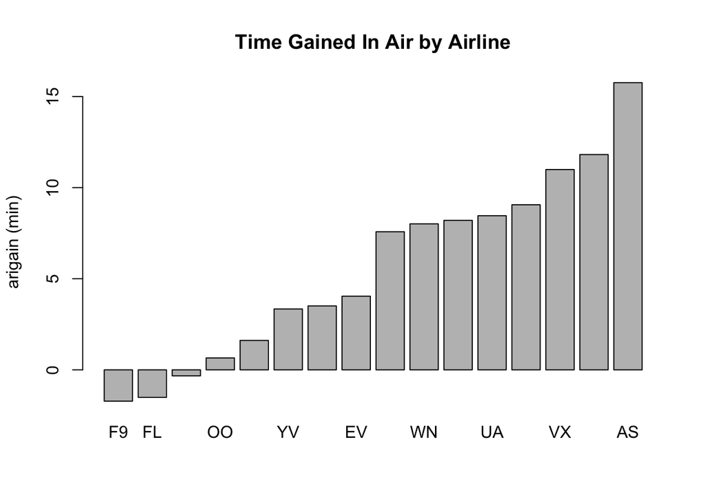

2. Which origination airport (there are three) has the least amount of arrival delay on average?

```
## [1] "JFK  has the least amount of arrival delay on average"
```

3. (This is a tough one) Build a function that takes one input: Month of Travel - and outputs the origination airport that has the least arrival delay for that month. Use the function to figure out the best origination airport for the month of June.

```
## [1] "the best origination airport for the month of June is:  LGA"
```

4. (This is a REALLY tough one) Assume that you fly from NYC to Atlanta pretty often. You are interested in figuring out whether you should fly in morning (4am - 12Noon), afternoon (12Noon - 4pm), evening (4pm - 8pm) or night (8pm - 4am) if you are interested in having least amount of arrival delay. You also want to know whether this changes by different month of departure.

```
## [1] "You should leave in the  morning  in general"
```

```
## [1] "You should leave in the  morning in month  1"
## [1] "You should leave in the  night in month  2"
## [1] "You should leave in the  morning in month  3"
## [1] "You should leave in the  morning in month  4"
## [1] "You should leave in the  morning in month  5"
## [1] "You should leave in the  morning in month  6"
## [1] "You should leave in the  morning in month  7"
## [1] "You should leave in the  morning in month  8"
## [1] "You should leave in the  morning in month  9"
## [1] "You should leave in the  morning in month  10"
## [1] "You should leave in the  morning in month  11"
## [1] "You should leave in the  morning in month  12"
```

5. (This one is pretty difficult as well) You would like to show the relationship between distance covered by the flight and airgain made by the flight graphically. This is an open ended question - build the best graphics (build several if you feel appropriate) that effectively conveys the relationship between distance and airgain. Explore the impact of origin airport and time of departure (morning, afternoon, evening, night - see Q4 above) on the above relationship graphically.

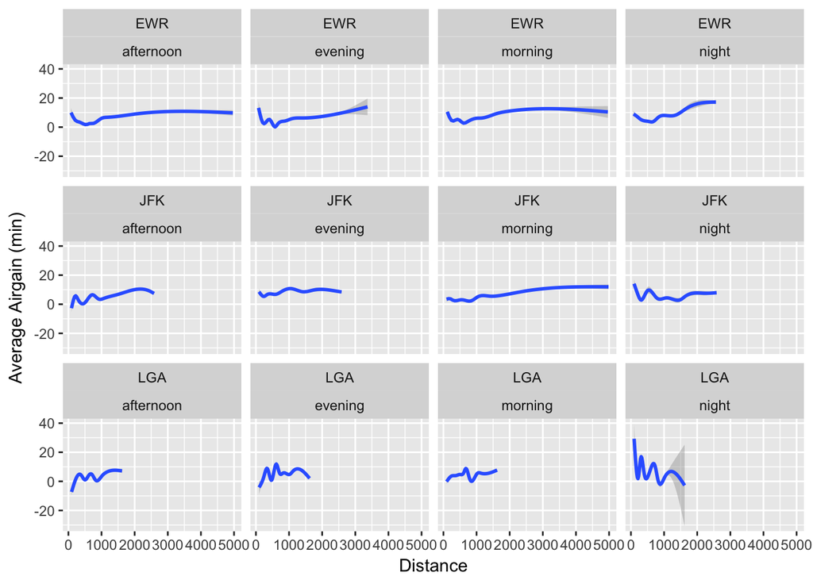